# Automated Public Science Communication

Damien Dupré

DCU Business School, Dublin City University

uRos 2026, Paris · 19 November 2026

## The Problem

### Statistics stay where they are published

National statistical offices release thousands of tables a year. Most are read by people who **already know where to look**.

### Citizens are in their feeds

People find information on social media. Posting there by hand, **for every release**, does not scale.

**Question:** can R turn every new official release into a readable chart in the public’s feed, with **no one in the loop**?

## Where It Started

[figure not shown]

### pumpsie_bot, 2023

- Yesterday’s fuel prices from **pumps.ie**, by county, posted on Twitter
- The cheapest station in each county, and the change since the day before
- The same recipe: get the data, draw it, post it, repeat
- Twitter’s API changes pushed the next bot to an **open platform**

## Meet `csoie_bot`

Check

Which CSO tables have a new release?

csodata

Fetch

Download it from the PxStat API

csodata

Plot

Choose and draw a chart automatically

ggplot2

Post

Publish image, text and alt text

bskyr

One R script, open source, run on a schedule by **GitHub Actions**. No server, no manual step.

## Why Bluesky?

### An open protocol

Bluesky runs on the **AT Protocol**. Posting from code is free and documented.

### App passwords

The bot logs in with a revocable **app password**, never the account password.

### Already in R

The **bskyr** package wraps authentication, image upload and alt text in one call.

# Architecture

Problem Architecture Challenges Results

## Scheduled, Not Hosted

```yaml
# .github/workflows/cso_bot.yml (excerpt)
on:
  schedule:
    # every 30 min, 10:00 to 18:30 UTC
    - cron: '*/30 10-18 * * *'
concurrency: cso-bluesky-bot     # one run at a time

jobs:
  check-and-post:
    runs-on: ubuntu-latest
    steps:
      - uses: actions/checkout@v4
      - uses: r-lib/actions/setup-r@v2
      - uses: r-lib/actions/setup-r-dependencies@v2
        with:                        # cached binaries
          packages: any::bskyr any::csodata any::ggplot2
      - run: Rscript bot_cso_bluesky.R
        env:
          BLUESKY_CSOIE_APP_USER: ${{ secrets.BLUESKY_CSOIE_APP_USER }}
          BLUESKY_CSOIE_APP_PASS: ${{ secrets.BLUESKY_CSOIE_APP_PASS }}
      - if: ${{ !cancelled() }}      # even if the bot failed
        run: |
          git add data/
          git commit -m "Update posted tables" || exit 0
          git pull --rebase && git push
```

- A fresh R session on every run: **no server to maintain**
- Packages come as **cached binaries**: a run takes about two minutes
- The bot **commits its own memory**: a log of every post and every failure
- Free for a public repository

## What Is New Today?

```r
# tables the CSO updated in the last week
toc <- cso_get_toc(from_date = as.character(Sys.Date() - 7))

# when each table was last posted, from the bot's own log
last_posted <- posted |>
  mutate(last_posted = as.Date(posted_date)) |>
  slice_max(last_posted, n = 1, by = id, with_ties = FALSE) |>
  select(id, last_posted)

# due: released since yesterday and not posted since that release,
# minus releases that have already failed three times
due <- toc |>
  mutate(release_date = as.Date(LastModified)) |>
  filter(release_date >= Sys.Date() - 1) |>
  left_join(last_posted, by = "id") |>
  filter(is.na(last_posted) | release_date > last_posted) |>
  anti_join(given_up, by = c("id", "release_date")) |>
  arrange(desc(LastModified))   # newest first

df <- cso_get_data(due$id[1], pivot_format = "tall")
```

- A table is **due** when the CSO releases it after its last post
- **Newest first**, at most **3 per run**, 30 s apart, so the feed and the rate limit cope
- Data comes back **tall**: one row per value, whatever the table

# Challenges

Problem Architecture Challenges Results

## Challenge 1: One Rule, Every Table Shape

| The table has… | The bot draws… |
| --- | --- |
| A time dimension and categories | Coloured lines, at most **6** groups, extra categories as facets (at most **12**) |
| A time dimension only | A single line |
| Monthly data over several years | **Year-over-year** lines: months on the x axis, the latest year in blue over grey past years |
| Categories only | A horizontal bar chart of the top **12** values |
| Nothing it can plot | Skips the table, logs the reason |

Totals (*Total*, *All*, *Both*, *State*) are dropped from lines and bars. Every dimension not on the chart is **held at its total, never averaged**.

The same idea, as a package: ggauto by Nicola Rennie chooses a ggplot2 chart type from whether the variables are continuous, categorical or dates.

## Challenge 2: Secrets in a Public Repository

### The risk

The code is open so others can reuse it. The bot still needs a password to post.

### The response

Credentials live in **GitHub Secrets**, reach R as environment variables, and are an **app password** that can be revoked in one click.

```r
# log in once per run; save_auth = FALSE keeps the session token off disk
auth <- bs_auth(
  user      = Sys.getenv("BLUESKY_CSOIE_APP_USER"),
  pass      = Sys.getenv("BLUESKY_CSOIE_APP_PASS"),
  save_auth = FALSE
)
bs_post(text, images = chart_file, images_alt = alt_text, auth = auth)
```

Every post carries **alt text**, so the charts reach screen-reader users too.

## Challenge 3: Failing Quietly, Retrying Later

### API down

The CSO catalogue can’t be reached

### Exit cleanly

`tryCatch()` returns `NULL`; the next run tries again

### Odd table

No numeric values, or no shape the rules can plot

### Skip and log

The reason goes in `skipped_tables.csv`; after **3** failures that release is given up

### Post rejected

Bluesky refuses the post

### Stop and retry

The run stops; the next run tries the same table again

### Crash mid-run

R dies after some posts are out

### Nothing lost

Each post is logged as it is made, and the log is committed even when the run fails

# Results

Problem Architecture Challenges Results

## Eight Months Without Intervention

### 1,484

charts posted

### 159

days with posts

### 41

posts on the busiest day

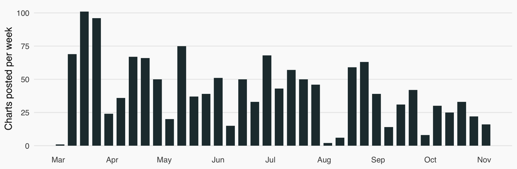

## What I Got Wrong

### A memory of IDs

The log only recorded which tables had been posted, so each table was posted once. Eight months of updates never reached the feed.

### A memory of releases

A table is due whenever the CSO releases it after its last post.

### A schedule taken on trust

The cron asks for a run every 30 minutes. Over the last two months, GitHub started it about twice a day.

### Plan for the runs you get

Newest releases first, so the few runs go to today’s figures.

Neither showed in the feed, where every post looked fine. Both were in the records: the bot’s own log and GitHub’s run history.

## What Worked

### Rules beat perfection

Not every chart is beautiful. A simple, **predictable** chart for every table is better than a perfect chart for a few.

### Metadata is the bottleneck

Good charts need clean **time and category columns**. Consistent table structure helps machines as much as people.

### Reusable by design

Swap `csodata` for another office’s API and **the rest of the pipeline stays the same**.

For statistical offices: an automated feed is a **cheap, transparent** complement to press releases, not a replacement.

Beyond the CSO: data.gov.ie runs on CKAN and harvests the CSO’s tables every night. With [ckanr](https://docs.ropensci.org/ckanr/), `package_search()` sorted by `metadata_modified` does what `cso_get_toc()` does here, on any CKAN portal.

## Thank You

Questions?

damien.dupre@dcu.ie

github.com/damien-dupre/csoie_bot

[@csoiebot.bsky.social](https://bsky.app/profile/csoiebot.bsky.social)

[figure not shown]

[figure not shown]

Want to build one for your own data? Connect with me on LinkedIn [linkedin.com/in/damien-dupre](https://www.linkedin.com/in/damien-dupre/) Scan the code, or search Damien Dupré